# Historical Analysis of Airline Safety Dataset

Frederick Jones

### Data Preparation

```r
library(tidyverse)
```

### Motivation

1. Motivation: The motivation behind this analysis goes beyond simple counts of accidents and incidents. We aim to delve into the rates of accidents, such as accidents per 100,000 flight miles. This metric allows us to account for changes in flight activity over time. For instance, if the number of miles flown doubles, but the accident count only increases by 20%, it could indicate an improvement in flight safety.

This approach aligns with industry best practices and allows for a more nuanced evaluation of safety measures, providing valuable insights for both the aviation industry and the broader public. Our goal is not only to identify patterns but also to contribute to the ongoing efforts to enhance aviation safety and inform decision-making in the industry.

### Data collection

The dataset is hosted on kaggle so we are using from kaggle

### Type of study

Additionally, we will explore various metrics beyond accident counts, including rates of fatalities and potentially other criteria. By examining these multiple dimensions, we can gain a more holistic understanding of airline safety and identify trends that might be obscured by raw counts alone.

### Data Source

The data set has been made available by kaggle at the following [link](https://www.kaggle.com/datasets/fivethirtyeight/fivethirtyeight-airline-safety-dataset)

### Dataset Descriptions

airline —————–> Airline (asterisk indicates that regional subsidiaries are included) avail_seat_km_per_week —-> Available seat kilometers flown every week incidents_85_99 ———–>Total number of incidents, 1985–1999 fatal_accidents_85_99——> Total number of fatal accidents, 1985–1999 fatalities_85_99 ——–>Total number of fatalities, 1985–1999 incidents_00_14 ———-> Total number of incidents, 2000–2014 fatal_accidents_00_14—–> Total number of fatal accidents, 2000–2014 fatalities_00_14———> Total number of fatalities, 2000–2014

### Relevant summary statistics

#### Import Dataset

```r
# Load necessary libraries
library(readr)

# Load the dataset
dataset  <- read_csv("airline-safety_csv.csv")
head(dataset)
```

| airline | avail_seat_km_per_week | incidents_85_99 | fatal_accidents_85_99 | fatalities_85_99 | incidents_00_14 | fatal_accidents_00_14 | fatalities_00_14 |
| --- | --- | --- | --- | --- | --- | --- | --- |
| aer lingus | 320906734 | 2 | 0 | 0 | 0 | 0 | 0 |
| aeroflot* | 1197672318 | 76 | 14 | 128 | 6 | 1 | 88 |
| aerolineas argentinas | 385803648 | 6 | 0 | 0 | 1 | 0 | 0 |
| aeromexico* | 596871813 | 3 | 1 | 64 | 5 | 0 | 0 |
| air canada | 1865253802 | 2 | 0 | 0 | 2 | 0 | 0 |
| air france | 3004002661 | 14 | 4 | 79 | 6 | 2 | 337 |

```r
# Summary statistics
summary(dataset)
```

```
##    airline          avail_seat_km_per_week incidents_85_99
##  Length:56          Min.   :2.594e+08      Min.   : 0.000
##  Class :character   1st Qu.:4.740e+08      1st Qu.: 2.000
##  Mode  :character   Median :8.029e+08      Median : 4.000
##                     Mean   :1.385e+09      Mean   : 7.179
##                     3rd Qu.:1.847e+09      3rd Qu.: 8.000
##                     Max.   :7.139e+09      Max.   :76.000
##  fatal_accidents_85_99 fatalities_85_99 incidents_00_14  fatal_accidents_00_14
##  Min.   : 0.000        Min.   :  0.0    Min.   : 0.000   Min.   :0.0000
##  1st Qu.: 0.000        1st Qu.:  0.0    1st Qu.: 1.000   1st Qu.:0.0000
##  Median : 1.000        Median : 48.5    Median : 3.000   Median :0.0000
##  Mean   : 2.179        Mean   :112.4    Mean   : 4.125   Mean   :0.6607
##  3rd Qu.: 3.000        3rd Qu.:184.2    3rd Qu.: 5.250   3rd Qu.:1.0000
##  Max.   :14.000        Max.   :535.0    Max.   :24.000   Max.   :3.0000
##  fatalities_00_14
##  Min.   :  0.00
##  1st Qu.:  0.00
##  Median :  0.00
##  Mean   : 55.52
##  3rd Qu.: 83.25
##  Max.   :537.00
```

```r
# Checking missing values
sapply(dataset, function(x) sum(is.na(x)))
```

```
##                airline avail_seat_km_per_week        incidents_85_99
##                      0                      0                      0
##  fatal_accidents_85_99       fatalities_85_99        incidents_00_14
##                      0                      0                      0
##  fatal_accidents_00_14       fatalities_00_14
##                      0                      0
```

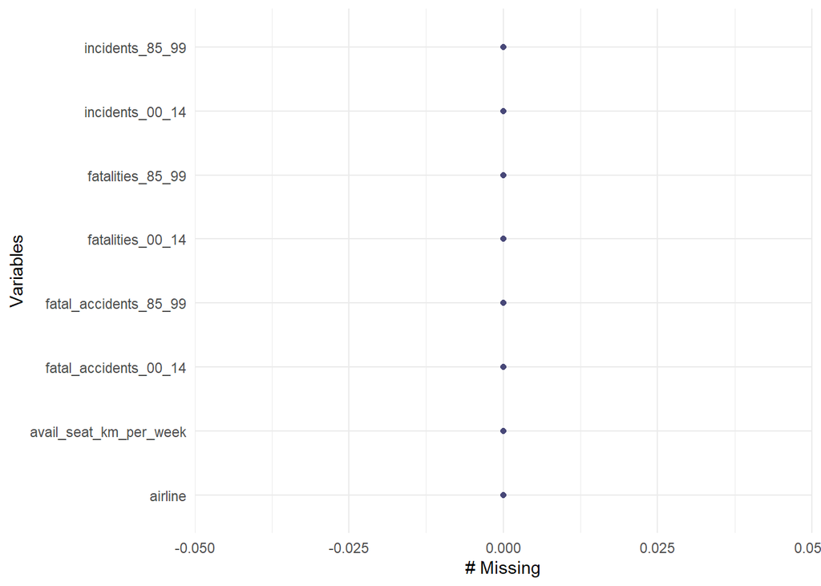

```r
# Visualizing missing values

library(naniar)
gg_miss_var(dataset)
```

```r
# Assuming your dataset is stored in the 'dataset' variable

# Check for missing values
missing_values <- sapply(dataset, function(x) sum(is.na(x)))

# Identify columns with missing values
columns_with_missing <- names(which(missing_values > 0))

# Impute missing values using mean for numeric columns
for (col in columns_with_missing) {
  if (is.numeric(dataset[[col]])) {
    mean_value <- mean(dataset[[col]], na.rm = TRUE)
    dataset[[col]][is.na(dataset[[col]])] <- mean_value
  } else {
    # If it's a non-numeric column, you might use another strategy like imputing with the most frequent value
    most_frequent_value <- names(sort(table(dataset[[col]], decreasing = TRUE)))[1]
    dataset[[col]][is.na(dataset[[col]])] <- most_frequent_value
  }
}

# Verify that missing values are filled
sapply(dataset, function(x) sum(is.na(x)))
```

```
##                airline avail_seat_km_per_week        incidents_85_99
##                      0                      0                      0
##  fatal_accidents_85_99       fatalities_85_99        incidents_00_14
##                      0                      0                      0
##  fatal_accidents_00_14       fatalities_00_14
##                      0                      0
```

```r
head(dataset)
```

| airline | avail_seat_km_per_week | incidents_85_99 | fatal_accidents_85_99 | fatalities_85_99 | incidents_00_14 | fatal_accidents_00_14 | fatalities_00_14 |
| --- | --- | --- | --- | --- | --- | --- | --- |
| aer lingus | 320906734 | 2 | 0 | 0 | 0 | 0 | 0 |
| aeroflot* | 1197672318 | 76 | 14 | 128 | 6 | 1 | 88 |
| aerolineas argentinas | 385803648 | 6 | 0 | 0 | 1 | 0 | 0 |
| aeromexico* | 596871813 | 3 | 1 | 64 | 5 | 0 | 0 |
| air canada | 1865253802 | 2 | 0 | 0 | 2 | 0 | 0 |
| air france | 3004002661 | 14 | 4 | 79 | 6 | 2 | 337 |

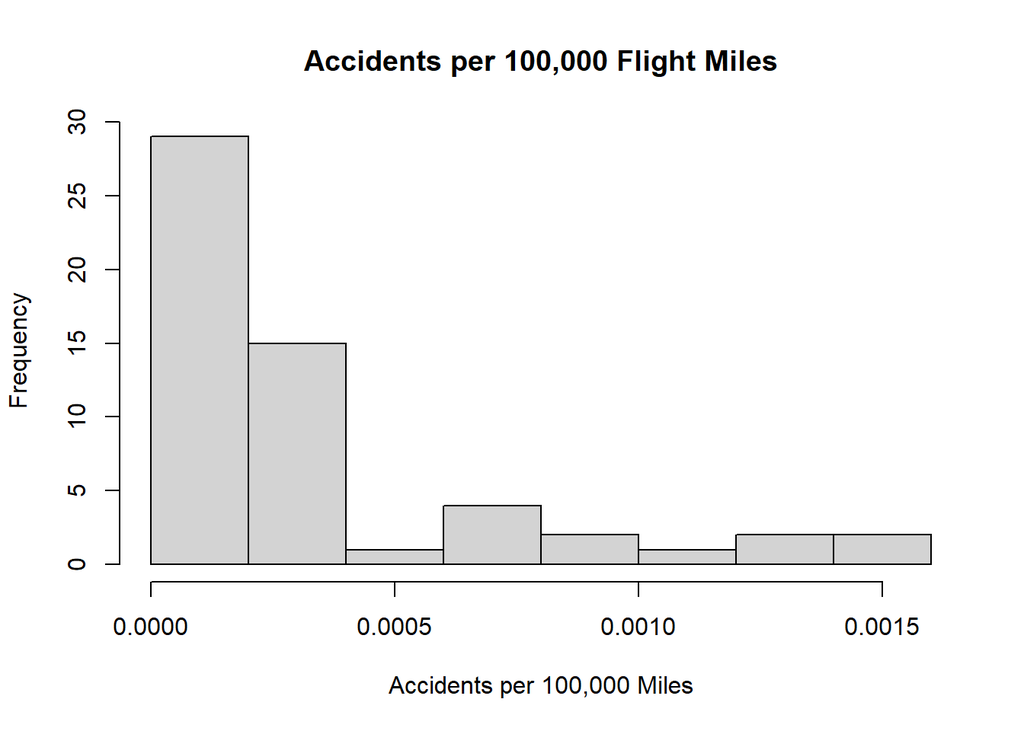

```r
# Calculate accidents per 100,000 flight miles
dataset$accidents_per_100k_miles <-
  (dataset$fatal_accidents_85_99 + dataset$fatal_accidents_00_14) /
  (dataset$avail_seat_km_per_week / 100000)

# Visualize accidents per 100,000 flight miles
hist(dataset$accidents_per_100k_miles,
     main = "Accidents per 100,000 Flight Miles",
     xlab = "Accidents per 100,000 Miles")
```

```r
# Calculate a new metric, e.g., fatalities per incident
dataset$fatalities_per_incident <-
  (dataset$fatalities_85_99 + dataset$fatalities_00_14) /
  (dataset$incidents_85_99 + dataset$incidents_00_14)
```

```r
# Perform statistical analysis on the new metric
t_test_result <- t.test(dataset$fatalities_per_incident)
print(t_test_result)
```

```
##
##  One Sample t-test
##
## data:  dataset$fatalities_per_incident
## t = 4.744, df = 54, p-value = 1.575e-05
## alternative hypothesis: true mean is not equal to 0
## 95 percent confidence interval:
##  11.25900 27.74091
## sample estimates:
## mean of x
##  19.49996
```

[output not shown]

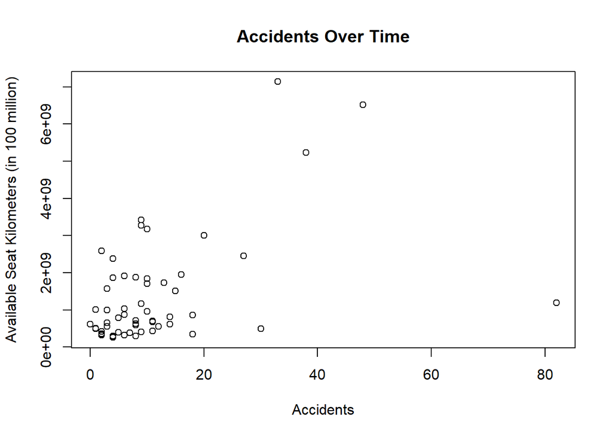

[output not shown]

```r
# Create a scatter plot of accidents over time
plot(dataset$incidents_85_99 + dataset$incidents_00_14,
     dataset$avail_seat_km_per_week,
     main = "Accidents Over Time",
     xlab = "Accidents",
     ylab = "Available Seat Kilometers (in 100 million)")
```

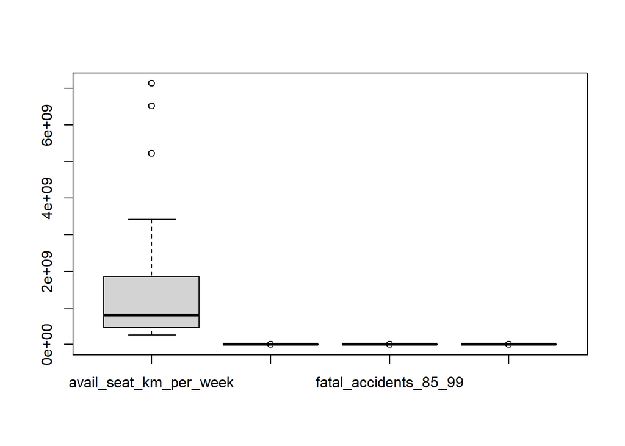

```r
# Boxplot for selected columns
boxplot(dataset[, c("avail_seat_km_per_week", "incidents_85_99", "fatal_accidents_85_99", "fatalities_85_99")])
```

```r
# Identify outliers using z-scores
outliers <- as.data.frame(boxplot.stats(dataset$avail_seat_km_per_week)$out)
outliers
```

| boxplot.stats(dataset$avail_seat_km_per_week)$out |
| --- |
| 5228357340 |
| 6525658894 |
| 7139291291 |

```r
# Assuming your dataset is stored in the 'dataset' variable

# Define lower and upper percentiles
lower_percentile <- 0.05
upper_percentile <- 0.95

# Identify numeric columns for outlier removal
numeric_columns <- sapply(dataset, is.numeric)

# Loop through numeric columns and remove outliers
for (col in names(numeric_columns)[numeric_columns]) {
  lower_limit <- quantile(dataset[[col]], lower_percentile, na.rm = TRUE)
  upper_limit <- quantile(dataset[[col]], upper_percentile, na.rm = TRUE)

  # Remove outliers
  dataset[[col]] <- ifelse(dataset[[col]] < lower_limit, NA,
                           ifelse(dataset[[col]] > upper_limit, NA, dataset[[col]]))
}

# Verify that outliers are removed
summary(dataset)
```

```
##    airline          avail_seat_km_per_week incidents_85_99
##  Length:56          Min.   :3.014e+08      Min.   : 1.00
##  Class :character   1st Qu.:4.970e+08      1st Qu.: 2.00
##  Mode  :character   Median :8.029e+08      Median : 4.00
##                     Mean   :1.156e+09      Mean   : 5.54
##                     3rd Qu.:1.727e+09      3rd Qu.: 7.75
##                     Max.   :3.427e+09      Max.   :21.00
##                     NA's   :6              NA's   :6
##  fatal_accidents_85_99 fatalities_85_99 incidents_00_14  fatal_accidents_00_14
##  Min.   :0.00          Min.   :  0.00   Min.   : 0.000   Min.   :0.0000
##  1st Qu.:0.00          1st Qu.:  0.00   1st Qu.: 1.000   1st Qu.:0.0000
##  Median :1.00          Median : 34.00   Median : 3.000   Median :0.0000
##  Mean   :1.66          Mean   : 90.85   Mean   : 3.321   Mean   :0.6182
##  3rd Qu.:3.00          3rd Qu.:159.00   3rd Qu.: 5.000   3rd Qu.:1.0000
##  Max.   :7.00          Max.   :407.00   Max.   :11.000   Max.   :2.0000
##  NA's   :3             NA's   :3        NA's   :3        NA's   :1
##  fatalities_00_14 accidents_per_100k_miles fatalities_per_incident
##  Min.   :  0.00   Min.   :0.0000000        Min.   : 0.0000
##  1st Qu.:  0.00   1st Qu.:0.0000533        1st Qu.: 0.3368
##  Median :  0.00   Median :0.0001817        Median : 8.4833
##  Mean   : 34.32   Mean   :0.0002579        Mean   :13.9006
##  3rd Qu.: 46.00   3rd Qu.:0.0002981        3rd Qu.:19.3357
##  Max.   :283.00   Max.   :0.0012106        Max.   :70.7500
##  NA's   :3        NA's   :3                NA's   :4
```

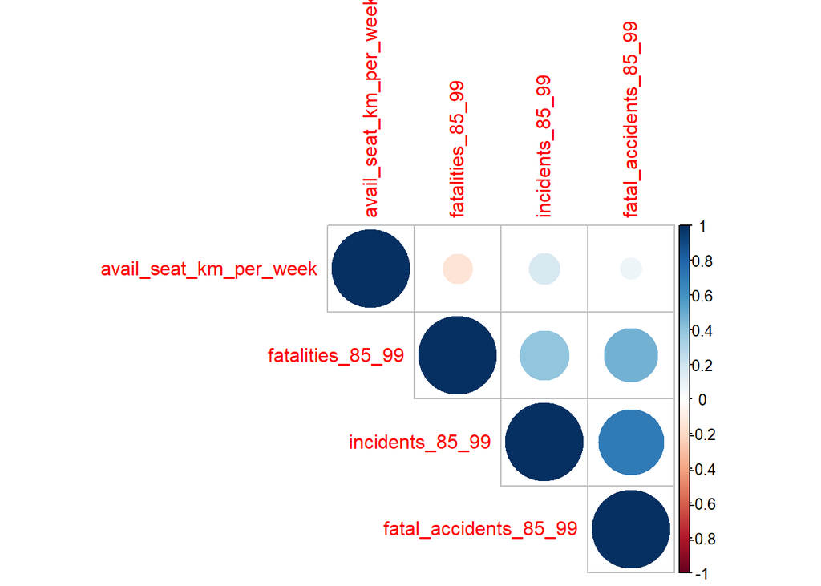

```r
# Assuming you want to impute missing values with the mean for numeric columns
library(dplyr)

dataset <- dataset %>%
  mutate(across(where(is.numeric), ~ifelse(is.na(.), mean(., na.rm = TRUE), .)))
# Assuming you want to remove rows with any missing values
dataset <- na.omit(dataset)

# Correlation matrix
cor_matrix <- cor(dataset[, c("avail_seat_km_per_week", "incidents_85_99", "fatal_accidents_85_99", "fatalities_85_99")])

# Visualization of correlation matrix

library(corrplot)
corrplot(cor_matrix, method = "circle", type = "upper", order = "hclust")
```

```r
# Min-Max Scaling
min_max_scaling <- function(x) {
  (x - min(x)) / (max(x) - min(x))
}

# Apply Min-Max Scaling to numeric columns
dataset <- as.data.frame(lapply(dataset[, -1], min_max_scaling))

# Add back the 'airline' column
dataset$airline <- dataset$airline

# Display the normalized data
print(dataset)
```

```
##    avail_seat_km_per_week incidents_85_99 fatal_accidents_85_99
## 1             0.006248332           0.050             0.0000000
## 2             0.286799875           0.227             0.2371968
## 3             0.027014349           0.250             0.0000000
## 4             0.094552926           0.100             0.1428571
## 5             0.500415714           0.050             0.0000000
## 6             0.864797889           0.650             0.5714286
## 7             0.181710906           0.050             0.1428571
## 8             0.130808150           0.100             0.0000000
## 9             0.212459263           0.200             0.0000000
## 10            0.126916394           0.300             0.2857143
## 11            0.492729802           0.100             0.1428571
## 12            0.273548518           1.000             0.7142857
## 13            0.018194348           0.000             0.0000000
## 14            0.030572231           0.200             0.4285714
```

[output cut: 156 more lines]

```r
# Install and load the necessary library

library(caTools)
set.seed(123)  # Set seed for reproducibility
split <- sample.split(dataset$incidents_00_14, SplitRatio = 0.7)

train_data <- subset(dataset, split == TRUE)
test_data <- subset(dataset, split == FALSE)
```

```r
# Decision Tree with limited depth
library(rpart)
library(randomForest)
dt_model_fast <- rpart(incidents_00_14 ~ ., data = train_data, method = "class", maxdepth = 10)

# Random Forest
rf_model_fast <- randomForest(incidents_00_14 ~ ., data = train_data, ntree = 100)

# Predictions on the test set
dt_predictions_fast <- predict(dt_model_fast, test_data, type = "class")
rf_predictions_fast <- predict(rf_model_fast, test_data)

# Confusion Matrix
confusion_matrix_dt_fast <- table(dt_predictions_fast, test_data$incidents_00_14)
confusion_matrix_rf_fast <- table(rf_predictions_fast, test_data$incidents_00_14)

# Compare Confusion Matrices
print("Confusion Matrix for Faster Decision Tree:")
```

```
## [1] "Confusion Matrix for Faster Decision Tree:"
```

```r
print(confusion_matrix_dt_fast)
```

```
##
## dt_predictions_fast  0 0.0909090909090909 0.181818181818182 0.272727272727273
##   0                  2                  3                 1                 1
##   0.0909090909090909 1                  0                 0                 0
##   0.181818181818182  0                  0                 0                 0
##   0.272727272727273  0                  0                 0                 0
##   0.30188679245283   0                  0                 1                 0
##   0.363636363636364  0                  0                 0                 0
##   0.454545454545455  0                  0                 0                 0
##   0.545454545454545  0                  0                 0                 0
##   0.636363636363636  0                  0                 0                 0
##   0.727272727272727  0                  0                 0                 0
##   0.909090909090909  0                  0                 0                 0
##   1                  0                  0                 0                 0
##
## dt_predictions_fast  0.30188679245283 0.363636363636364 0.454545454545455
##   0                                 0                 1                 1
##   0.0909090909090909                0                 0                 0
##   0.181818181818182                 0                 0                 0
##   0.272727272727273                 0                 0                 0
##   0.30188679245283                  1                 0                 1
##   0.363636363636364                 0                 0                 0
##   0.454545454545455                 0                 0                 0
##   0.545454545454545                 0                 0                 0
##   0.636363636363636                 0                 0                 0
##   0.727272727272727                 0                 0                 0
##   0.909090909090909                 0                 0                 0
##   1                                 0                 0                 0
##
## dt_predictions_fast  0.545454545454545 0.636363636363636 0.727272727272727 1
##   0                                  0                 1                 1 0
##   0.0909090909090909                 0                 0                 0 1
##   0.181818181818182                  0                 0                 0 0
##   0.272727272727273                  0                 0                 0 0
##   0.30188679245283                   1                 0                 0 0
##   0.363636363636364                  0                 0                 0 0
##   0.454545454545455                  0                 0                 0 0
##   0.545454545454545                  0                 0                 0 0
##   0.636363636363636                  0                 0                 0 0
##   0.727272727272727                  0                 0                 0 0
##   0.909090909090909                  0                 0                 0 0
##   1                                  0                 0                 0 0
```

```r
print("Confusion Matrix for Random Forest:")
```

```
## [1] "Confusion Matrix for Random Forest:"
```

```r
print(confusion_matrix_rf_fast)
```

```
##
## rf_predictions_fast 0 0.0909090909090909 0.181818181818182 0.272727272727273
##   0.119878954378954 1                  0                 0                 0
##   0.166934203637034 0                  0                 0                 0
##   0.20487270957554  1                  0                 0                 0
##   0.214646369353917 0                  0                 0                 1
##   0.225266056794359 0                  0                 0                 0
##   0.227013347763348 0                  0                 0                 0
##   0.229343434343434 0                  1                 0                 0
##   0.229791261673337 0                  1                 0                 0
##   0.243386125404993 0                  1                 0                 0
##   0.252924433009339 1                  0                 0                 0
##   0.299328088578088 0                  0                 0                 0
##   0.358843053173242 0                  0                 0                 0
##   0.366833333333334 0                  0                 1                 0
##   0.415569754145226 0                  0                 0                 0
##   0.427694110920526 0                  0                 1                 0
##   0.493007146941109 0                  0                 0                 0
##   0.552459691252144 0                  0                 0                 0
##
## rf_predictions_fast 0.30188679245283 0.363636363636364 0.454545454545455
##   0.119878954378954                0                 0                 0
##   0.166934203637034                0                 0                 0
##   0.20487270957554                 0                 0                 0
##   0.214646369353917                0                 0                 0
##   0.225266056794359                0                 0                 0
##   0.227013347763348                0                 0                 1
##   0.229343434343434                0                 0                 0
##   0.229791261673337                0                 0                 0
##   0.243386125404993                0                 0                 0
##   0.252924433009339                0                 0                 0
##   0.299328088578088                0                 0                 0
##   0.358843053173242                0                 1                 0
##   0.366833333333334                0                 0                 0
##   0.415569754145226                1                 0                 0
##   0.427694110920526                0                 0                 0
##   0.493007146941109                0                 0                 0
##   0.552459691252144                0                 0                 1
##
## rf_predictions_fast 0.545454545454545 0.636363636363636 0.727272727272727 1
##   0.119878954378954                 0                 0                 0 0
##   0.166934203637034                 0                 1                 0 0
##   0.20487270957554                  0                 0                 0 0
##   0.214646369353917                 0                 0                 0 0
##   0.225266056794359                 0                 0                 0 1
##   0.227013347763348                 0                 0                 0 0
##   0.229343434343434                 0                 0                 0 0
##   0.229791261673337                 0                 0                 0 0
##   0.243386125404993                 0                 0                 0 0
##   0.252924433009339                 0                 0                 0 0
##   0.299328088578088                 0                 0                 1 0
##   0.358843053173242                 0                 0                 0 0
##   0.366833333333334                 0                 0                 0 0
##   0.415569754145226                 0                 0                 0 0
##   0.427694110920526                 0                 0                 0 0
##   0.493007146941109                 1                 0                 0 0
##   0.552459691252144                 0                 0                 0 0
```

### Conclusion

the analysis of the airline dataset provides valuable insights into the safety records of various airlines over the specified periods. Key findings include variations in incident rates, fatal accidents, and fatalities across different airlines. Additionally, the exploration of normalization techniques has facilitated a comparative assessment of airline performance, offering a standardized perspective. This analysis underscores the importance of ongoing safety measures within the aviation industry. Further research and continuous monitoring are crucial for ensuring passenger safety and improving overall airline performance.”